# TA Session 1

Chi-Yuan Fang

March 2, 2021

# 1 Introduction

## 1.1 TA Information

TA: Chi-Yuan Fang

TA sessions: Tuesday 1:20 – 3:10 PM (SS 501)

Email: r09323017@ntu.edu.tw

Office hours: Friday 2:00 – 3:30 PM or by appointments (SS 643)

Class group on Facebook: Statistics (Fall 2020) and Econometrics (Spring 2021) https://www.facebook.com/groups/452292659024369/

Because screens are not clear in SS 501, I will provide the link of live streaming in the group.

## 1.2 TA Sessions Schedule

| Week | TA Sessions | Quiz | Content | Remind |
| --- | --- | --- | --- | --- |
| 1 | 02/23: No class |  |  |  |
| 2 | 03/02: Class 1 |  | Function, Confidence Interval, T test | 03/10 Turn in HW1 |
| 3 | 03/09: Class 2 |  |  | 03/10 Turn in HW1, 03/16 Quiz 1 |
| 4 | 03/16: Class 3 | Quiz 1 |  | 03/24 Turn in HW2 |
| 5 | 03/23: Class 4 |  |  | 03/24 Turn in HW2, 03/30 Quiz 2 |
| 6 | 03/30: Class 5 | Quiz 2 |  | 04/14 Turn in HW3 |
| 7 | 04/06: No class |  |  | 04/14 Turn in HW3 |
| 8 | 04/13: Class 6 |  |  | 04/14 Turn in HW3, 04/20 Quiz 3 |
| 9 | 04/20: Class 7 | Quiz 3 |  | **04/28 Midterm** |
| 10 | 04/27: Class 8 |  | Review and Q&A | **04/28 Midterm**, 05/05 Turn in HW4 |
| 11 | 05/04: Class 9 |  |  | 05/05 Turn in HW4, 05/11 Quiz 4 |
| 12 | 05/11: Class 10 | Quiz 4 |  | 05/19 Turn in HW5 |
| 13 | 05/18: Class 11 |  |  | 05/19 Turn in HW5, 05/25 Quiz 5 |
| 14 | 05/25: Class 12 | Quiz 5 |  | 06/02 Turn in HW6 |
| 15 | 06/01: Class 13 |  |  | 06/02 Turn in HW6, 06/08 Quiz 6 |
| 16 | 06/08: Class 14 | Quiz 6 | Review and Q&A | **06/16 Final Exam** |
| 17 | 06/15: No class |  |  | **06/16 Final Exam** |
| 18 | 06/22: No class |  |  |  |

## 1.3 Reference

Introduction to Econometrics with R

https://www.econometrics-with-r.org

R for Data Science

https://r4ds.had.co.nz

R Markdown

https://rmarkdown.rstudio.com

Introduction to R Markdown

https://rpubs.com/brandonkopp/RMarkdown

What is a good book on learning R with examples?

https://www.quora.com/What-is-a-good-book-on-learning-R-with-examples

# 2 Large-Sample Approximations to Sampling Distributions

## 2.1 The Law of Large Numbers and Consistency

### 2.1.1 Figure 2.8 [p.87]

Figure 2.8: Sampling Distribution of the Sample Average of $n$ Bernoulli Random Variables [p.87]

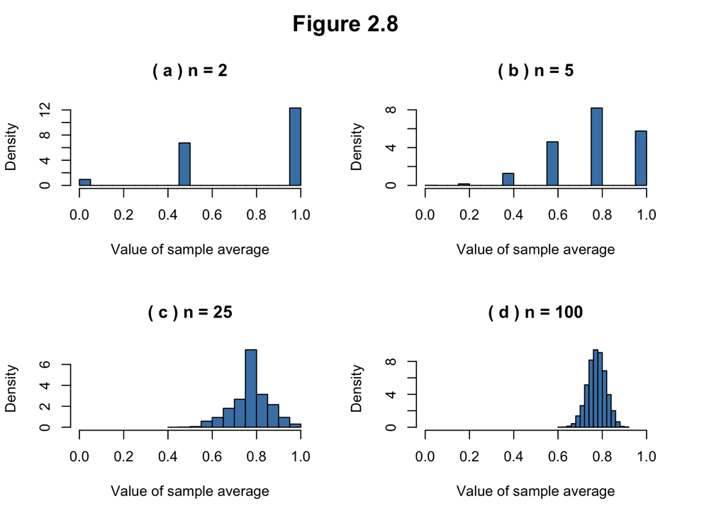

```r
# p.87 Figure 2.8

# set sample size and number of samples
Figure28 <- function(n, mu, reps, index){

  # n x reps sample matrix
  samples <- replicate(reps, rbinom(n, size = 1, prob = mu))

  # compute sample mean
  sample.avgs <- colMeans(samples)

  # histogram
  hist(sample.avgs,
       probability = TRUE, # freq = FALSE
       col = "steelblue",
       xlim = c(0, 1),
       xlab = "Value of sample average",
       main = paste("(", index, ") n =", n)) #
}

# subdivide the plot panel into a 2-by-2 array
# https://www.r-bloggers.com/2012/06/two-tips-adding-title-for-graph-with-multiple-plots-add-significance-asterix-onto-a-boxplot/
par(mfrow=c(2, 2),oma = c(0, 0, 2, 2))

# set the number of repetitions and the sample sizes
reps <- 10000
sample.sizes <- c(2, 5, 25, 100)

# set seed for reproducibility
set.seed(12345)

for (i in sample.sizes){
  Figure28(i, 0.78, reps, letters[which(sample.sizes == i)])
}

mtext("Figure 2.8", outer = TRUE, cex = 1.3, font = 2)
```

## 2.2 The Central Limit Theorem

### 2.2.1 Figure 2.9 [p.88]

Figure 2.9: Distribution of the Standardized Sample Average of $n$ Bernoulli Random Variables with $p = 0.78$ [p.88]

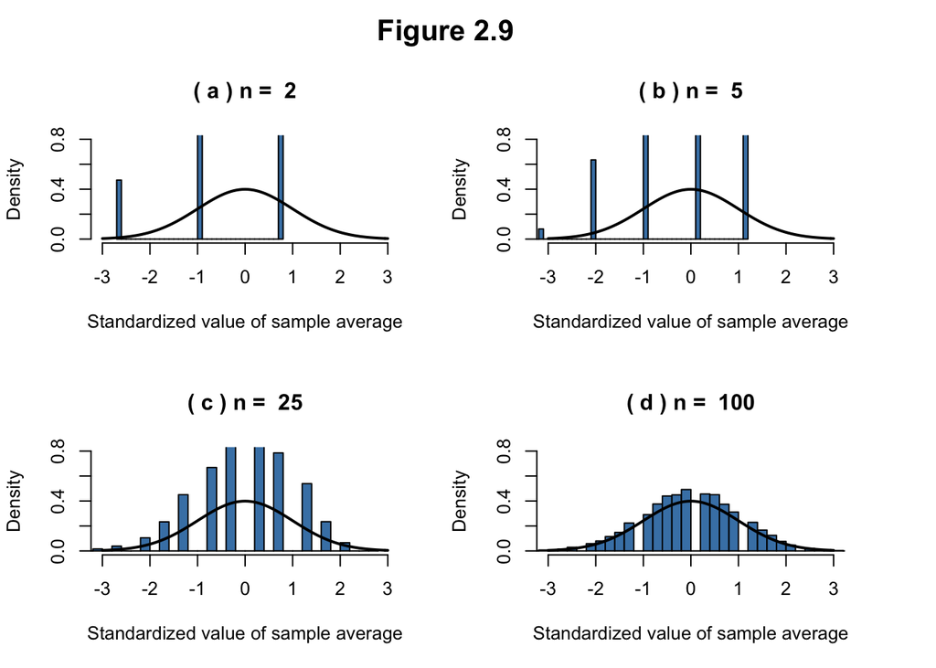

```r
# p.88 Figure 2.9

Figure29 <- function(n, mu, reps, index){
  # initialize the vector of sample means
  samplemean <- rep(0, reps) # 0 for reps times

  # initialize the vector of standardized sample means
  stdsamplemean <- rep(0, reps) # 0 for reps times

  # inner loop (loop over repetitions)
  for (i in 1:reps){
    # generate sample
    x <- rbinom(n, 1, mu) # mu = 0.78

    # sample mean
    samplemean[i] <- mean(x)

    # standardized
    stdsamplemean[i] <- (mean(x) - mu)/sqrt(mu*(1-mu)/n)
  }

  # plot histogram
  hist(stdsamplemean,
       probability = TRUE, # freq = FALSE
       col = "steelblue",
       breaks = 40,
       xlim = c(-3, 3), ylim = c(0, 0.8),
       xlab = "Standardized value of sample average",
       main = paste("(", index, ") n = ", n))

  # overlay the N(0,1) density for every iteration
  curve(dnorm(x), lwd = 2, col = "black", add = TRUE)

}

# subdivide the plot panel into a 2-by-2 array
# https://www.r-bloggers.com/2012/06/two-tips-adding-title-for-graph-with-multiple-plots-add-significance-asterix-onto-a-boxplot/
par(mfrow=c(2, 2),oma = c(0, 0, 2, 2))

# set the number of repetitions and the sample sizes
reps <- 10000
sample.sizes <- c(2, 5, 25, 100)

# set seed for reproducibility
set.seed(12345)

for (i in sample.sizes){
  Figure29(i, 0.78, reps, letters[which(sample.sizes == i)])
}

mtext("Figure 2.9", outer = TRUE, cex = 1.3, font = 2)
```

### 2.2.2 Figure 2.10 [p.90]

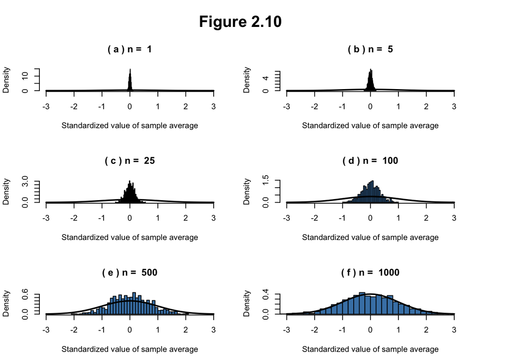

```r
# p.90 Figure 2.10

# https://stackoverflow.com/questions/4807398/how-to-generate-distributions-given-mean-sd-skew-and-kurtosis-in-r

# https://stackoverflow.com/questions/1497539/fitting-a-density-curve-to-a-histogram-in-r

library("PearsonDS")

Figure210 <- function(n, mu, var, skew, kurt, reps, index){
  # set moments
  moments <- c(mean = mu, variance = var, skewness = skew, kurtosis = kurt)

  # initialize the vector of sample means
  samplemean <- rep(0, reps) # 0 for reps times

  # initialize the vector of standardized sample means
  stdsamplemean <- rep(0, reps) # 0 for reps times

  # inner loop (loop over repetitions)
  for (i in 1:reps){
    # generate sample
    x <- rpearson(reps, moments = moments)

    # sample mean
    samplemean[i] <- mean(x)

    # standardized
    stdsamplemean[i] <- (mean(x) - mu)/sqrt(var/n)
  }

  # plot histogram
  hist(stdsamplemean,
       probability = TRUE, # freq = FALSE
       col = "steelblue",
       breaks = 40,
       xlim = c(-3, 3), #ylim = c(0, 0.8),
       xlab = "Standardized value of sample average",
       main = paste("(", index, ") n = ", n))

  # overlay the N(0,1) density for every iteration
  curve(dnorm(x), lwd = 2, col = "black", add = TRUE)

}

# subdivide the plot panel into a 3-by-2 array
# https://www.r-bloggers.com/2012/06/two-tips-adding-title-for-graph-with-multiple-plots-add-significance-asterix-onto-a-boxplot/
par(mfrow=c(3, 2), oma = c(0, 0, 3, 3))

# set the number of repetitions and the sample sizes
reps <- 1000
sample.sizes <- c(1, 5, 25, 100, 500, 1000)

# set seed for reproducibility
set.seed(12345)

for (i in sample.sizes){
  Figure210(i, 0, 1, 0.1, 3, reps, letters[which(sample.sizes == i)])
}

mtext("Figure 2.10", outer = TRUE, cex = 1.3, font = 2)
```

# 3 Empircial Exercise 3.1

> On the text website, http://www.pearsonglobaleditions.com, you will find the data file **CPS96_15**, which contains an extended version of the data set used in Table 3.1 of the text for the years 1996 and 2015. It contains data on full-time workers, ages 25–34, with a high school diploma or a B.A./B.S. as their highest degree. A detailed description is given in **CPS96_15_Description**, available on the website. Use these data to complete the following.
> 1. 1. Compute the sample mean for average hourly earnings ($AHE$) in 1996 and 2015.
>    2. Compute the sample standard deviation for $AHE$ in 1996 and 2015.
>    3. Construct a 95% confidence interval for the population means of $AHE$ in 1996 and 2015.
>    4. Construct a 95% confidence interval for the change in the population means of $AHE$ between 1996 and 2015.

**Solution**

```r
# import data
library(readxl)
CPS96_15 <- read_xlsx("CPS96_15/CPS96_15.xlsx")

# data: 1996
CPS96 <- CPS96_15[CPS96_15$year == 1996,]

# data: 2015
CPS15 <- CPS96_15[CPS96_15$year == 2015,]

# i. sample mean # ii. standard error # iii. 95% CI
E31a <- function(x){
  # i. sample mean
  mu <- mean(x)

  # ii. standard error = sample standard deviation (s) / sqrt(n)
  se <- sd(x)/sqrt(length(x))

  # test
  test <- t.test(x,
                 alternative = c("two.sided"),
                 mu = 0, # H0
                 conf.level = 0.95) # alpha = 0.05

  # iii. 95% confidence interval
  lower <- round(test$conf.int[1], digit = 4)
  upper <- round(test$conf.int[2], digit = 4)
  CI <- paste(lower, "-"  ,upper)

  Table <- data.frame(mu, se, CI)
  colnames(Table) <- c("Mean", "Standard Error", "95% Confidence Interval")

  Table

}

tapply(CPS96_15$ahe, CPS96_15$year, E31a)
```

```
## $`1996`
##       Mean Standard Error 95% Confidence Interval
## 1 12.69326     0.08139908       12.5337 - 12.8528
##
## $`2015`
##       Mean Standard Error 95% Confidence Interval
## 1 21.23744      0.1439117       20.9553 - 21.5195
```

```r
# iv. 95% confidence interval for difference

t.test(CPS15$ahe, CPS96$ahe,
       alternative = c("two.sided"),
       mu = 0, # H0
       var.equal = FALSE,
       conf.level = 0.95) # alpha = 0.05
```

```
##
##  Welch Two Sample t-test
##
## data:  CPS15$ahe and CPS96$ahe
## t = 51.677, df = 11049, p-value < 2.2e-16
## alternative hypothesis: true difference in means is not equal to 0
## 95 percent confidence interval:
##  8.220087 8.868268
## sample estimates:
## mean of x mean of y
##  21.23744  12.69326
```

> 2. In 2015, the value of the Consumer Price Index (CPI) was 237.0. In 1996, the value of the CPI was 156.9. Repeat (a), but use AHE measured in real 2015 dollars ($2015); that is, adjust the 1996 data for the price inflation that occurred between 1996 and 2015.

**Solution**

```r
# data: 1996
CPS96 <- CPS96_15[CPS96_15$year == 1996,]

# CPI
CPI_96 <- 156.9
CPI_15 <- 237

# adjusted 1996 AHE in $2015
ahe_adjust <- CPS96$ahe * (CPI_15/CPI_96)

# data: 1996 including adjusted 1996 AHE in $2015
CPS96 <- cbind(CPS96, ahe_adjust)

# i. sample mean
# ii. sample standard deviation
# iii. 95% confidence interval
# for adjusted 1996 AHE in $2015
E31a(CPS96$ahe_adjust)
```

```
##       Mean Standard Error 95% Confidence Interval
## 1 19.17338      0.1229546       18.9323 - 19.4144
```

```r
# iv. 95% confidence interval for difference
t.test(CPS15$ahe, CPS96$ahe_adjust,
       alternative = c("two.sided"),
       mu = 0, # H0
       var.equal = FALSE,
       conf.level = 0.95) # alpha = 0.05
```

```
##
##  Welch Two Sample t-test
##
## data:  CPS15$ahe and CPS96$ahe_adjust
## t = 10.905, df = 13113, p-value < 2.2e-16
## alternative hypothesis: true difference in means is not equal to 0
## 95 percent confidence interval:
##  1.693038 2.435086
## sample estimates:
## mean of x mean of y
##  21.23744  19.17338
```

> 3. If you were interested in the change in workers’ purchasing power from 1996 to 2015, would you use the results from (a) or (b)? Explain.

**Solution**

The results from part (b) adjust for changes in purchasing power. These results should be used.

> 4. Using the data for 2015:
>    1. Construct a 95% confidence interval for the mean of $AHE$ for high school graduates.
>    2. Construct a 95% confidence interval for the mean of $AHE$ for workers with a college degree.
>    3. Construct a 95% confidence interval for the difference between the two means.

**Solution**

```r
# data: high school in 2015
CPS15hs <- CPS15[CPS15$bachelor == 0, ]

# data: college in 2015
CPS15col <- CPS15[CPS15$bachelor == 1, ]

# i. 95% CI for AHE in high school # ii. 95% CI for AHE in college
tapply(CPS15$ahe, CPS15$bachelor, E31a)
```

```
## $`0`
##       Mean Standard Error 95% Confidence Interval
## 1 16.38111      0.1471396       16.0926 - 16.6696
##
## $`1`
##       Mean Standard Error 95% Confidence Interval
## 1 25.61503      0.2155545       25.1924 - 26.0376
```

```r
# iii. 95% CI for difference
t.test(CPS15hs$ahe, CPS15col$ahe,
       alternative = c("two.sided"),
       mu = 0, # H0
       var.equal = FALSE,
       conf.level = 0.95) # alpha = 0.05
```

```
##
##  Welch Two Sample t-test
##
## data:  CPS15hs$ahe and CPS15col$ahe
## t = -35.381, df = 6463.4, p-value < 2.2e-16
## alternative hypothesis: true difference in means is not equal to 0
## 95 percent confidence interval:
##  -9.745543 -8.722304
## sample estimates:
## mean of x mean of y
##  16.38111  25.61503
```

> 5. Repeat (d) using the 1996 data expressed in $2015.

**Solution**

```r
# data: high school in 2015
CPS96hs <- CPS96[CPS96$bachelor == 0, ]

# data: college in 2015
CPS96col <- CPS96[CPS96$bachelor == 1, ]

# i. 95% CI for AHE in high school # ii. 95% CI for AHE in college
tapply(CPS96$ahe_adjust, CPS96$bachelor, E31a)
```

```
## $`0`
##       Mean Standard Error 95% Confidence Interval
## 1 16.26823      0.1299935       16.0134 - 16.5231
##
## $`1`
##       Mean Standard Error 95% Confidence Interval
## 1 23.03803       0.205452       22.6352 - 23.4409
```

```r
# iii. 95% CI for difference
t.test(CPS96col$ahe_adjust, CPS96hs$ahe_adjust,
       alternative = c("two.sided"),
       mu = 0, # H0
       var.equal = FALSE,
       conf.level = 0.95) # alpha = 0.05
```

```
##
##  Welch Two Sample t-test
##
## data:  CPS96col$ahe_adjust and CPS96hs$ahe_adjust
## t = 27.845, df = 4581.8, p-value < 2.2e-16
## alternative hypothesis: true difference in means is not equal to 0
## 95 percent confidence interval:
##  6.293168 7.246445
## sample estimates:
## mean of x mean of y
##  23.03803  16.26823
```

> 6. Using appropriate estimates, confidence intervals, and test statistics, answer the following questions:
>    1. Did real (inflation-adjusted) wages of high school graduates increase from 1996 to 2015?
>    2. Did real wages of college graduates increase?
>    3. Did the gap between earnings of college and high school graduates increase? Explain.

**Solution**

- **Prepare**

$H_0: \overline{wage}_{2015}^{hs} - \overline{wage}_{1996}^{hs} = 0$ v.s. $H_1: \overline{wage}_{2015}^{hs} - \overline{wage}_{1996}^{hs} \neq 0$

Let the significance level be 0.05.

- **Calculate**

Test statistics:
$$\begin{align}
t
& = \frac{\left(\overline{w}_{2015}^{hs} - \overline{w}_{1996}^{hs}\right) - 0}{\sqrt{\frac{s_{2015,hs}^{2}}{n_{2015}^{hs}} + \frac{s_{1996,hs}^{2}}{n_{1996}^{hs}}}}
\end{align}$$

95% confidence interval:
$$\begin{align}
\left(\overline{w}_{2015}^{hs} - \overline{w}_{1996}^{hs}\right) \pm Z_{0.025} \cdot \sqrt{\frac{s_{2015,hs}^{2}}{n_{2015}^{hs}} + \frac{s_{1996,hs}^{2}}{n_{1996}^{hs}}}
\end{align}$$

```r
E31fi <- function(x1, x2){
  # mean
  mu1 <- mean(x1); mu2 <- mean(x2)

  # s
  SD1 <- sd(x1); SD2 <- sd(x2)

  # n
  n1 <- length(x1); n2 <- length(x2)

  # difference in mean
  mu <- mu2 - mu1

  # difference in standard error
  se <- sqrt(SD1^2/n1 + SD2^2/n2)

  # 95% confidence interval
  lower <- round(mu - qnorm(0.975, mean = 0, sd = 1)*se, digit = 4)
  upper <- round(mu + qnorm(0.975, mean = 0, sd = 1)*se, digit = 4)
  CI <- paste(lower, "-"  ,upper)

  Table <- data.frame(mu, se, CI)
  colnames(Table) <- c("Mean", "Standard Error", "95% Confidence Interval")

  Table

}

E31fi(CPS96hs$ahe_adjust, CPS15hs$ahe)
```

```
##        Mean Standard Error 95% Confidence Interval
## 1 0.1128797      0.1963374        -0.2719 - 0.4977
```

```r
t.test(CPS15hs$ahe, CPS96hs$ahe_adjust,
       alternative = c("two.sided"),
       mu = 0, # H0
       var.equal = FALSE,
       conf.level = 0.95) # alpha = 0.05
```

```
##
##  Welch Two Sample t-test
##
## data:  CPS15hs$ahe and CPS96hs$ahe_adjust
## t = 0.57493, df = 6714.1, p-value = 0.5654
## alternative hypothesis: true difference in means is not equal to 0
## 95 percent confidence interval:
##  -0.2720040  0.4977633
## sample estimates:
## mean of x mean of y
##  16.38111  16.26823
```

- **Conclude**

Because $p-value > 0.05$, we do not reject $H_0$. There is no evidence that real (inflation-adjusted) wages of high school graduates increase from 1996 to 2015.

- **Prepare**

$H_0: \overline{wage}_{2015}^{col} - \overline{wage}_{1996}^{col} = 0$ v.s. $H_1: \overline{wage}_{2015}^{col} - \overline{wage}_{1996}^{col} \neq 0$

Let the significance level be 0.05.

- **Calculate**

Test statistics:
$$\begin{align}
t
& = \frac{\left(\overline{w}_{2015}^{col} - \overline{w}_{1996}^{col}\right) - 0}{\sqrt{\frac{s_{2015,col}^{2}}{n_{2015}^{col}} + \frac{s_{1996,col}^{2}}{n_{1996}^{col}}}}
\end{align}$$

95% confidence interval:
$$\begin{align}
\left(\overline{w}_{2015}^{col} - \overline{w}_{1996}^{col}\right) \pm Z_{0.025} \cdot \sqrt{\frac{s_{2015,col}^{2}}{n_{2015}^{col}} + \frac{s_{1996,col}^{2}}{n_{1996}^{col}}}
\end{align}$$

```r
E31fi(CPS96col$ahe_adjust, CPS15col$ahe)
```

```
##       Mean Standard Error 95% Confidence Interval
## 1 2.576997      0.2977822         1.9934 - 3.1606
```

```r
t.test(CPS15col$ahe, CPS96col$ahe_adjust,
       alternative = c("two.sided"),
       mu = 0, # H0
       var.equal = FALSE,
       conf.level = 0.95) # alpha = 0.05
```

```
##
##  Welch Two Sample t-test
##
## data:  CPS15col$ahe and CPS96col$ahe_adjust
## t = 8.654, df = 6245.3, p-value < 2.2e-16
## alternative hypothesis: true difference in means is not equal to 0
## 95 percent confidence interval:
##  1.993241 3.160752
## sample estimates:
## mean of x mean of y
##  25.61503  23.03803
```

- **Conclude**

Because $p-value < 0.05$, we reject $H_0$. There is statistically significance evidence that real (inflation-adjusted) wages of college graduates increase from 1996 to 2015.

- **Prepare**

$H_0: \overline{wage}_{2015}^{diff} - \overline{wage}_{1996}^{diff} = 0$ v.s. $H_1: \overline{wage}_{2015}^{diff} - \overline{wage}_{1996}^{diff} \neq 0$

Let the significance level be 0.05.

- **Calculate**

Test statistics:
$$\begin{align}
t
& = \frac{\left[ \left(\overline{w}_{2015}^{col} - \overline{w}_{2015}^{hs}\right) - \left(\overline{w}_{1996}^{col} - \overline{w}_{1996}^{hs}\right) \right] - 0}{\sqrt{ \left( \frac{s_{2015,col}^{2}}{n_{2015}^{col}} + \frac{s_{2015,hs}^{2}}{n_{2015}^{hs}} \right) + \left( \frac{s_{1996,col}^{2}}{n_{1996}^{col}} + \frac{s_{1996,hs}^{2}}{n_{1996}^{hs}} \right) }}
\end{align}$$

95% confidence interval:
$$\begin{align}
& \left[ \left(\overline{w}_{2015}^{col} - \overline{w}_{2015}^{hs}\right) - \left(\overline{w}_{1996}^{col} - \overline{w}_{1996}^{hs}\right) \right] \pm Z_{0.025} \cdot \sqrt{ \left( \frac{s_{2015,col}^{2}}{n_{2015}^{col}} + \frac{s_{2015,hs}^{2}}{n_{2015}^{hs}} \right) + \left( \frac{s_{1996,col}^{2}}{n_{1996}^{col}} + \frac{s_{1996,hs}^{2}}{n_{1996}^{hs}} \right) }
\end{align}$$

```r
E31fiii <- function(x11, x12, x21, x22){
  # mean
  mu11 <- mean(x11); mu12 <- mean(x12)
  mu21 <- mean(x21); mu22 <- mean(x22)

  # mu
  mu1 <- mu11 - mu12
  mu2 <- mu21 - mu22

  # SE
  SD11 <- sd(x11); SD12 <- sd(x12)
  SD21 <- sd(x21); SD22 <- sd(x22)

  # n
  n11 <- length(x11); n12 <- length(x12)
  n21 <- length(x21); n22 <- length(x22)

  SD1 <- sqrt(SD11^2/n11 + SD12^2/n12)
  SD2 <- sqrt(SD21^2/n21 + SD22^2/n22)

  # difference in mean
  mu <- mu2 - mu1

  # difference in standard error
  se <- sqrt(SD1^2 + SD2^2)

  # 95% confidence interval
  lower <- round(mu - qnorm(0.975, mean = 0, sd = 1)*se, digit = 4)
  upper <- round(mu + qnorm(0.975, mean = 0, sd = 1)*se, digit = 4)
  CI <- paste(lower, "-"  ,upper)

  Table <- data.frame(mu, se, CI)
  colnames(Table) <- c("Mean", "Standard Error", "95% Confidence Interval")

  Table
}

E31fiii(CPS96col$ahe_adjust, CPS96hs$ahe_adjust, CPS15col$ahe, CPS15hs$ahe)
```

```
##       Mean Standard Error 95% Confidence Interval
## 1 2.464117      0.3566828          1.765 - 3.1632
```

- **Conclude**

Because $0 \notin 95\%$ confidence interval, we reject $H_0$. There is statistically significance evidence that the gap between earnings of college and high school graduates increase.

> 7. Table 3.1 presents information on the gender gap for college graduates. Prepare a similar table for high school graduates, using the 1996 and 2015 data. Are there any notable differences between the results for high school and college graduates?

**Solution**

```r
E31g <- function(x){
  # sample mean
  mu <- mean(x)

  # standard deviation
  SD <- sd(x)

  # numbers of sample
  n <- length(x)

  Table <- data.frame(mu, SD, n)

  Table
}

# data: male in 1996
CPS96hsm <- CPS96hs[CPS96hs$female == 0, ]

# data: female in 1996
CPS96hsf <- CPS96hs[CPS96hs$female == 1, ]

# statistics: male and female in 1996
tapply(CPS96hs$ahe_adjust, CPS96hs$female, E31g)
```

```
## $`0`
##         mu       SD    n
## 1 17.78487 8.240476 2168
##
## $`1`
##         mu       SD    n
## 1 13.76968 5.830538 1316
```

```r
# difference in 1996
t.test(CPS96hsm$ahe_adjust, CPS96hsf$ahe_adjust,
       alternative = c("two.sided"),
       mu = 0, # H0
       var.equal = FALSE,
       conf.level = 0.95) # alpha = 0.05
```

```
##
##  Welch Two Sample t-test
##
## data:  CPS96hsm$ahe_adjust and CPS96hsf$ahe_adjust
## t = 16.795, df = 3402, p-value < 2.2e-16
## alternative hypothesis: true difference in means is not equal to 0
## 95 percent confidence interval:
##  3.546458 4.483924
## sample estimates:
## mean of x mean of y
##  17.78487  13.76968
```

```r
# statistics: male and female in 2015
tapply(CPS15hs$ahe, CPS15hs$female, E31g)
```

```
## $`0`
##         mu       SD    n
## 1 17.49846 9.026855 2222
##
## $`1`
##         mu       SD    n
## 1 14.20896 6.998409 1143
```

```r
# data: male in 2015
CPS15hsm <- CPS15hs[CPS15hs$female == 0, ]

# data: female in 2015
CPS15hsf <- CPS15hs[CPS15hs$female == 1, ]

# difference in 2015
t.test(CPS15hsm$ahe, CPS15hsf$ahe,
       alternative = c("two.sided"),
       mu = 0, # H0
       var.equal = FALSE,
       conf.level = 0.95) # alpha = 0.05
```

```
##
##  Welch Two Sample t-test
##
## data:  CPS15hsm$ahe and CPS15hsf$ahe
## t = 11.665, df = 2857.1, p-value < 2.2e-16
## alternative hypothesis: true difference in means is not equal to 0
## 95 percent confidence interval:
##  2.736560 3.842432
## sample estimates:
## mean of x mean of y
##  17.49846  14.20896
```